# Modelos de Regresión

## 1 Objetivos y Perspectiva general

En este notebook vamos a trabajar en un caso práctico de regresión utilizando un conjunto de datos referentes a la felicidad del año 2019: ([world happines](https://www.kaggle.com/datasets/unsdsn/world-happiness))

Este dataset incluye el ranking y la puntuación de felicidad de 156 países, basándose en seis factores clave: PIB per cápita, apoyo social, esperanza de vida saludable, libertad para tomar decisiones, generosidad y percepción de la corrupción.

¡Vamos allá!

## 2 Importación de librerías y paquetes

```python
# Librerías de análisis y tratamiento de datos
import pandas as pd
# Librerías para visualización de datos
import matplotlib.pyplot as plt
import seaborn as sns
# Modulos para partición de datos
from sklearn.model_selection import train_test_split
# Librerías para Modelos de ML
from sklearn.linear_model import LinearRegression, Ridge, Lasso
from sklearn.preprocessing import PolynomialFeatures
from sklearn.pipeline import make_pipeline
from scipy import stats
# Metricas de analisis
from sklearn.metrics import r2_score, mean_squared_error
from sklearn.preprocessing import StandardScaler
```

## 3 Lectura y visualización de datos

```python
# Importación del dataset
df = pd.read_csv(r".\datasets\happiness\2019.csv")
# Eliminación de columnas innecesarias
df = df.drop(['Overall rank','Country or region'],axis=1)
df.head()
```

|  | Score | GDP per capita | Social support | Healthy life expectancy | Freedom to make life choices | Generosity | Perceptions of corruption |
| --- | --- | --- | --- | --- | --- | --- | --- |
| 0 | 7.769 | 1.340 | 1.587 | 0.986 | 0.596 | 0.153 | 0.393 |
| 1 | 7.600 | 1.383 | 1.573 | 0.996 | 0.592 | 0.252 | 0.410 |
| 2 | 7.554 | 1.488 | 1.582 | 1.028 | 0.603 | 0.271 | 0.341 |
| 3 | 7.494 | 1.380 | 1.624 | 1.026 | 0.591 | 0.354 | 0.118 |
| 4 | 7.488 | 1.396 | 1.522 | 0.999 | 0.557 | 0.322 | 0.298 |

```python
# Visualización de información clave de cada campo
df.info()
```

```
<class 'pandas.core.frame.DataFrame'>
RangeIndex: 156 entries, 0 to 155
Data columns (total 7 columns):
 #   Column                        Non-Null Count  Dtype
---  ------                        --------------  -----
 0   Score                         156 non-null    float64
 1   GDP per capita                156 non-null    float64
 2   Social support                156 non-null    float64
 3   Healthy life expectancy       156 non-null    float64
 4   Freedom to make life choices  156 non-null    float64
 5   Generosity                    156 non-null    float64
 6   Perceptions of corruption     156 non-null    float64
dtypes: float64(7)
memory usage: 8.7 KB
```

## 4 Exploración de los datos (EDA)

Comenzamos con la exploración de datos para extraer conclusiones previas a la aplicaicón de modelos. Para ello, graficaremos la matriz de confusión apara analizar la correlación de las variables.

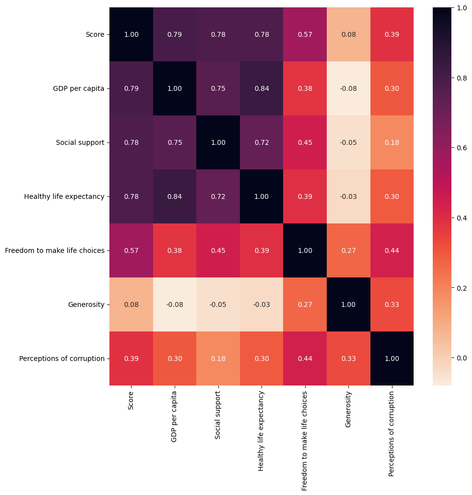

```python
# Graficación de matriz de confusión para análisis del dataset
plt.subplots(figsize=(10,10))
sns.heatmap(df.corr(), cmap = "rocket_r", annot=True, fmt=".2f")
plt.show()
```

En el siguiente gráfico, podemos ver la distribución de los datos que tenemos. Esto nos puede ayudar a saber si la información esta sesgada o si hay valores que predominen sobre el resto.

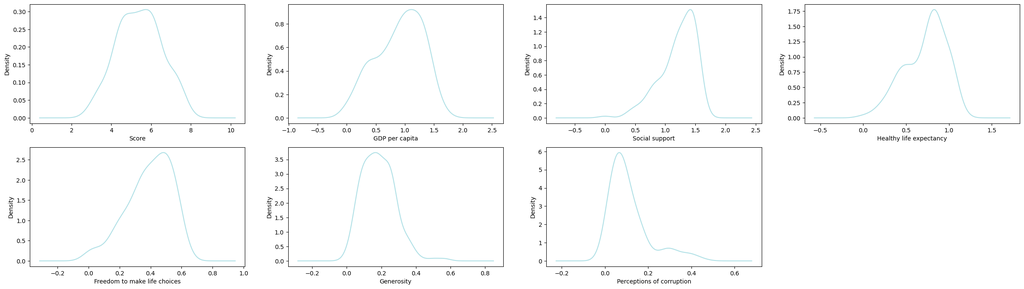

```python
# Análisis de la distribución de los datos
fig = plt.figure(figsize=(30, 8))

for i, column in enumerate(df):
    sub = fig.add_subplot(2, 4, i + 1)
    sub.set_xlabel(column)
    df[column].plot(kind='kde', color='powderblue')
    sub.set_xlabel(column)
```

Tal como se observa en los anteriores gráficos, se observa que no todos tienen una distribución uniforme, por lo tanto la idea seria estandarizar los datos. Esta es una forma de asegurarnos de que aplicaremos la uniformidad necesaria para garantizar la efectividad de sus análisis.

```python
# Normalización de los datos para poder extraer conclusiones más certeras
scaler = StandardScaler()

df[df.columns[1:]] = scaler.fit_transform(df[df.columns[1:]])
```

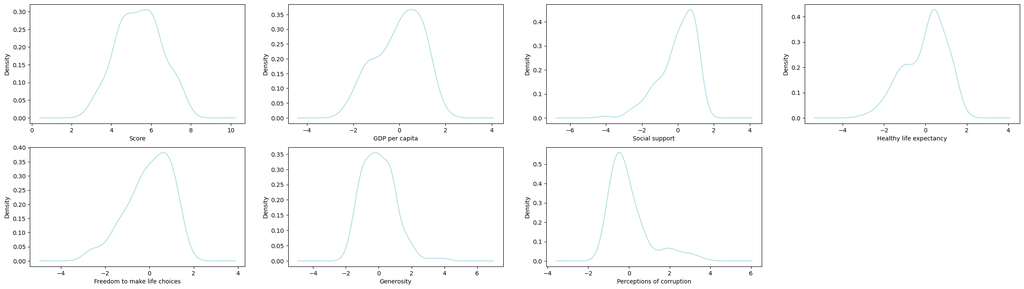

```python
# Análisis de la distribución de los datos aplicando normalización en los datos
fig = plt.figure(figsize=(30, 8))

for i, column in enumerate(df):
    sub = fig.add_subplot(2, 4, i + 1)
    sub.set_xlabel(column)
    df[column].plot(kind='kde', color='powderblue')
    sub.set_xlabel(column)
```

En la siguiente gráfica podemos ver las distribuciones de cada atributo respecto al *Score*. Este nos da una información muy similar a la matriz de confusión, indicandonos el nivel de correlación que hay entre unos y otros.

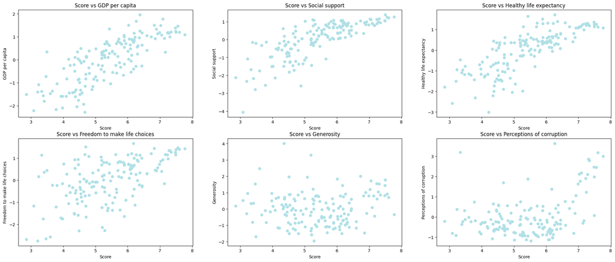

```python
# Análisis de la distribución de los datos en base al Score
target_attribute = 'Score'
other_columns = [col for col in df.columns if col != target_attribute]

fig = plt.figure(figsize=(25, 10))

for i, column in enumerate(other_columns):
    df[column] = stats.zscore(df[column])
    sub = fig.add_subplot(2, 3, i + 1)
    sub.scatter(df[target_attribute], df[column], color='powderblue')
    sub.set_xlabel(target_attribute)
    sub.set_ylabel(column)
    sub.set_title(f'{target_attribute} vs {column}')
```

## 5 Entrenamiento y Comparativa de los modelos

Procedemos con el entrenamiento de una serie de modelos de regresión explicados en los artículos teóricos publicados de modelos de regresión.

El objetivo es identificar cuál de todos ellos se adapta mejor a esta problemática de regresión dividiendo los datos en test y train para ver como se comportan cada uno.

Como hemos visto en la matriz de confusión y los gráficos, los atributos de *Generosity* y *Perceptions of corruption* no están aportando mucha información respecto al *Score*, que es el dato que queremos predecir. Por lo tanto, los descartaremos con la intención de quitar posible ruido en el modelo o que se confunda con estos datos.

```python
# Extracción de las variables independientes (X) y la variable dependiente (y)
X = df.drop(['Score', 'Generosity', 'Perceptions of corruption'], axis=1)
y = df["Score"]

# División del dataset en training y test
X_train, X_test, y_train, y_test = train_test_split(X, y, test_size=0.33, random_state=42)
```

```python
# Listado de modelos a entrenar
models = [LinearRegression(), Lasso(alpha=0.001), Ridge(alpha = 0.1), make_pipeline(PolynomialFeatures(degree=2, include_bias=False), LinearRegression())]
models_list = ["Linear Regression", "Lasso Regression", "Ridge Regression", "Polynomial Regression"]
mserrors = []
r2s = []
preds = []
# Entrenamiento de modelos y obteción de valores de predicción
for model in models:
    model.fit(X_train, y_train)
    y_pred = model.predict(X_test)
    preds.append(y_pred)
```

## 6 Evaluación de los resultados de los modelos

A continuación, procedemos a evaluar los resultados obtenidos del entrenamiento de los modelos.

```
                   Model       MSE        R2
0      Linear Regression  0.391274  0.595334
1       Lasso Regression  0.391075  0.595540
2       Ridge Regression  0.391212  0.595398
3  Polynomial Regression  0.330769  0.657910
```

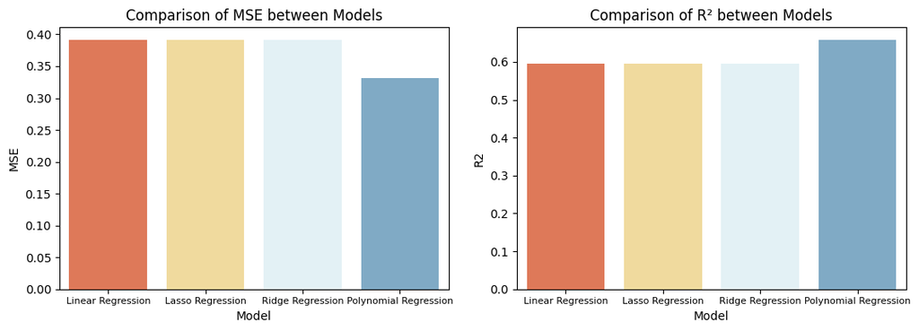

```python
# Definición de métricas de evaluación
metrics = []

for name, y_pred in zip(models_list, preds):
    mse_score = mean_squared_error(y_test, y_pred)
    r2 = r2_score(y_test, y_pred)
    metrics.append({'Model': name, 'MSE': mse_score, 'R2': r2})

metrics_df = pd.DataFrame(metrics)

print(metrics_df)

fig, ax = plt.subplots(1, 2, figsize=(11, 4))

# Graficación de los resultados
sns.barplot(x='Model', y='MSE', data=metrics_df, hue='Model', palette='RdYlBu', ax=ax[0])
ax[0].set_title("Comparison of MSE between Models")
ax[0].tick_params(axis='x', labelsize=8)

sns.barplot(x='Model', y='R2', data=metrics_df, hue='Model', palette='RdYlBu', ax=ax[1])
ax[1].set_title("Comparison of R² between Models")
ax[1].tick_params(axis='x', labelsize=8)

plt.tight_layout()
plt.show()
```

Podemos ver que el MSE mejor lo tiene la regresión polinómica, lo que sugiere que este modelo tiene mejor ajuste que los otros tres. Además, los modelos Lineal, Lasso y Ridge tienen valores muy similares, lo que nos indica que tienen rendimientos muy similares.

Para R2 nuevamente el que obtiene un mejor resultado es la regresión polinómica, lo que indica que este modelo se adapta mejor a la variabilidad que los otros modelos. De igual forma, Lineal, Lasso y Ridge dan resultados casi idénticos, lo que nos indica que la regularización de Lasso y Ridge en este caso no proporciona una mejora en comparación con la regresión lineal.

En los siguientes gráficos, podremos ver como la regresión Lineal, Lasso y Ridge tienen un rendimiento muy similar y la regresión polinómica suele tener ligeramente mejores resultados.

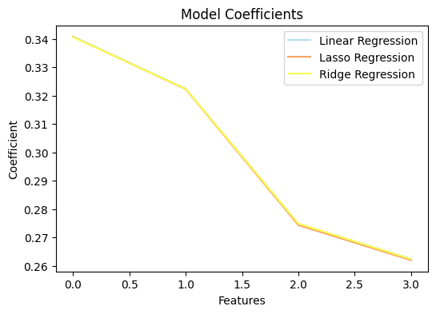

```python
# Graficacion del rendimiento de los modelos
plt.figure(figsize=(6, 4))
colors = ['powderblue', 'sandybrown', '#fdff52', '#9dc100']
i = 0
for name, model in zip(models_list, models):
    if name != 'Polynomial Regression':
        plt.plot(model.coef_, color=colors[i], label=name)
        i += 1
plt.title("Model Coefficients")
plt.xlabel("Features")
plt.ylabel("Coefficient")
plt.legend()
plt.show()
```

En el siguiente gráfico se observa que las predicciones obtenidas suelen quedar cerca del valor real, donde a partir de los 4 puntos de felicidad no suele fallar por más de un punto de diferencia. En los de por debajo de 4 puntos, que son errores más grandes, esto puede ser debido a que hay menos valores con una tasa de felicidad tan baja, haciendo que los modelos sea más complicado identificarlo.

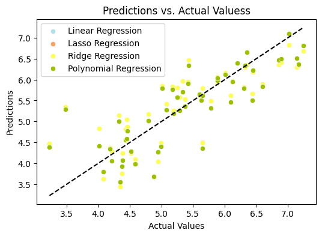

```python
# Graficación de los resultados de predicción vs valores reales
plt.figure(figsize=(6, 4))
i = 0
for name, y_pred in zip(models_list, preds):
    sns.scatterplot(x=y_test, y=y_pred, label=name, color=colors[i])
    i += 1
plt.plot([min(y_test), max(y_test)], [min(y_test), max(y_test)], color='black', linestyle='--')
plt.title("Predictions vs. Actual Valuess")
plt.xlabel("Actual Values")
plt.ylabel("Predictions")
plt.legend()
plt.show()
```

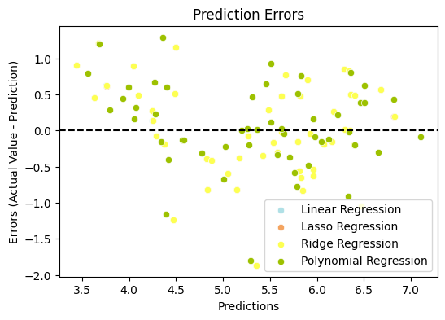

```python
# Graficación de los resultados obtenidos del modelo de regresión polinómica
plt.figure(figsize=(6, 4))
i = 0
for name, y_pred in zip(models_list, preds):
    errors = y_test - y_pred
    sns.scatterplot(x=y_pred, y=errors, label=name, color=colors[i])
    i += 1
plt.axhline(y=0, color='black', linestyle='--')
plt.title("Prediction Errors")
plt.xlabel("Predictions")
plt.ylabel("Errors (Actual Value - Prediction)")
plt.legend()
plt.show()
```

En este último gráfico podemos ver de manera visual como el modelo polinomial tiene unos resultados más certeros y como el error máximo no supera los dos puntos.

#### ¡Muchas gracias por leer nuestro artículo!